# Simulation

## SV model

$$Z_t = \varepsilon_t \exp(0.5X_t), \ \ X_t = a + b \ X_{t-1}+ c \ \eta_t, \ \ \ \ \ t\in \mathbb{Z}$$
where $\varepsilon_t \sim N(0,1)$, $\eta_t \sim N(0,1)$, $a=0.2$, $b=0.6$, and $c=0.9$.

### Model’s specific functions

```r
# function for generating sample {Xt,Zt} t=1,...,n
simulate_data = function(n_sample, cutoff=0.05){
    # generate sample {Zt}
    #n_sample = n_sample / (1 - 2*cutoff)
    n_sample = n_sample + 1
    burn_in = 100
    n = n_sample + burn_in
    Z = X = rep(NA,n)
    X[1] = 1
    for (i in 2:n) {
        X[i] = 0.5 + 0.6*(X[i-1]-0.5) + 0.9*rnorm(1,0,1) # 0.2+0.6*X[i-1]+0.9*rnorm(1,0,1)
        Z[i] = exp(0.5*X[i]) * rnorm(1,0,1)
    }
    X = X[-(1:(burn_in+1))]
    Z = Z[-(1:(burn_in+1))]

    # cutoff the tail of each end
    cuts = as.vector(quantile(X, probs=c(cutoff,1-cutoff))) # both ends of X
    index = which((X>cuts[1]) & (X<cuts[2]))
    X_cut = X[index]
    Z_cut = Z[index]

    return(list(X=X, Z=Z, X_cut=X_cut, Z_cut=Z_cut, cuts=cuts))
}
```

```r
# function for calculating theoretical conditional quantile
theo_con_q = function(x,p){
    exp(0.5*x) * qnorm(p,0,1,lower.tail=TRUE)
#   qnorm(p,0,exp(0.5*x),lower.tail=TRUE)
}
```

### Data Simulation

```r
# simulate a group of data
set.seed(123)
data = simulate_data(n_sample=500, cutoff=0.05)
X = data$X
Z = data$Z
X_cut = data$X_cut
Z_cut = data$Z_cut
```

```r
print("whole data")
```

```
## [1] "whole data"
```

```r
c(min(X),max(X))
```

```
## [1] -2.051452  4.708552
```

```r
c(min(Z),max(Z))
```

```
## [1] -9.257445 12.179952
```

```r
print("cutted data")
```

```
## [1] "cutted data"
```

```r
c(min(X_cut),max(X_cut))
```

```
## [1] -1.063019  2.489978
```

```r
c(min(Z_cut),max(Z_cut))
```

```
## [1] -7.866654  5.256707
```

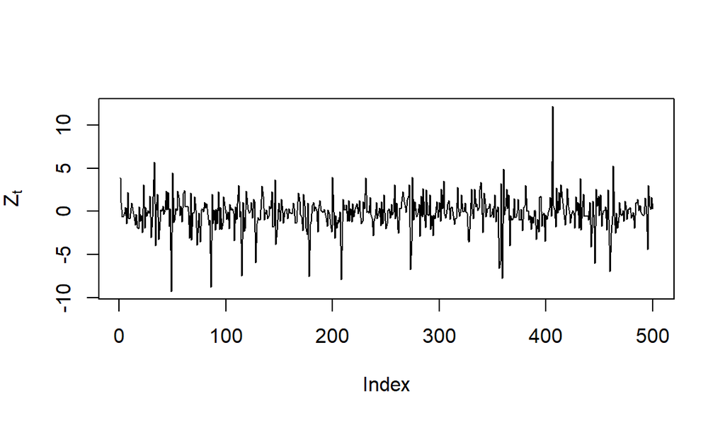

```r
# check the distribution of simulated data Zt
plot(Z, type="l", ylab=expression(Z[t]))
```

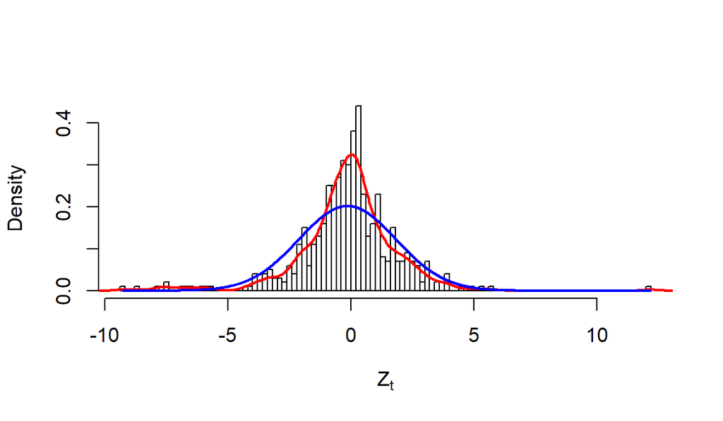

```r
hist(Z, breaks=100, freq=FALSE, main="", xlab=expression(Z[t]))
lines(density(Z, adjust=1),col="red",lwd=2) # kernel density estimation
zz = seq(min(Z),max(Z),0.01)
lines(zz, dnorm(zz,mean(Z),sd(Z)), col="blue",lwd=2)
```

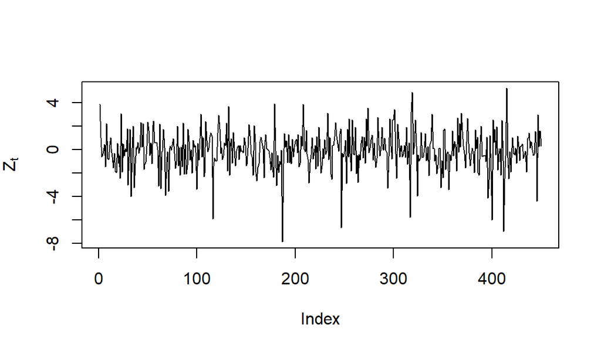

```r
plot(Z_cut, type="l", ylab=expression(Z[t]))
```

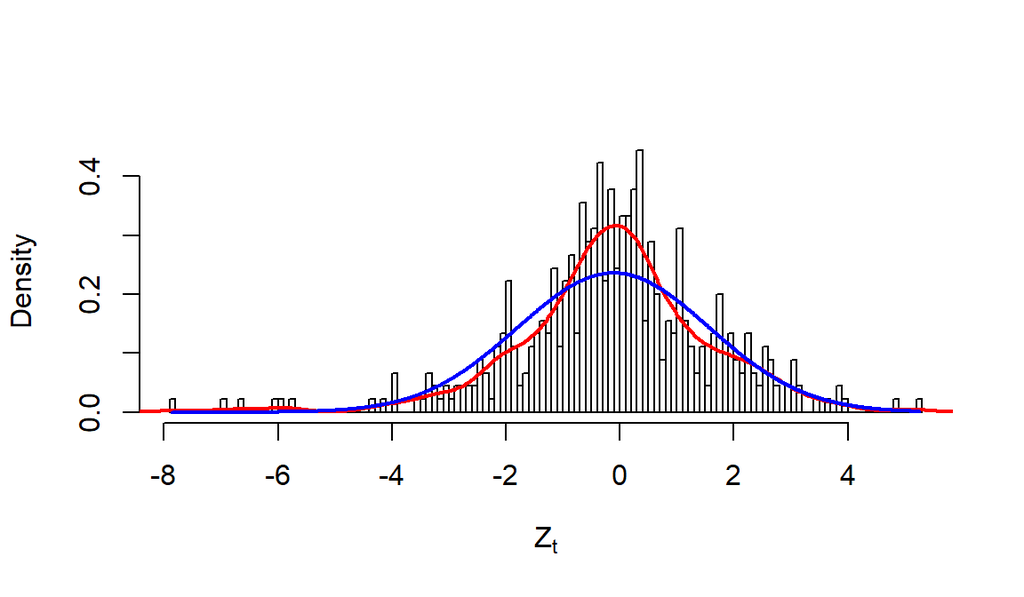

```r
hist(Z_cut, breaks=100, freq=FALSE, main="", xlab=expression(Z[t]))
lines(density(Z_cut, adjust=1),col="red",lwd=2) # kernel density estimation
zz_cut = seq(min(Z_cut),max(Z_cut),0.01)
lines(zz_cut, dnorm(zz_cut,mean(Z_cut),sd(Z_cut)), col="blue",lwd=2)
```

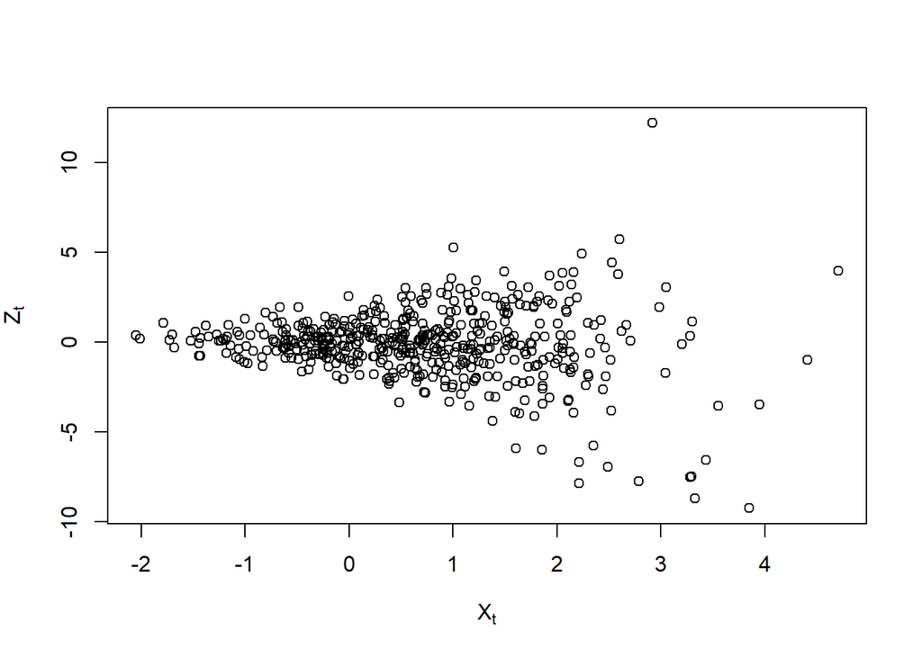

```r
# check the scatterplot of {Xt, Zt} t=1,...,n
plot(X, Z, xlab=expression(X[t]), ylab=expression(Z[t]))
```

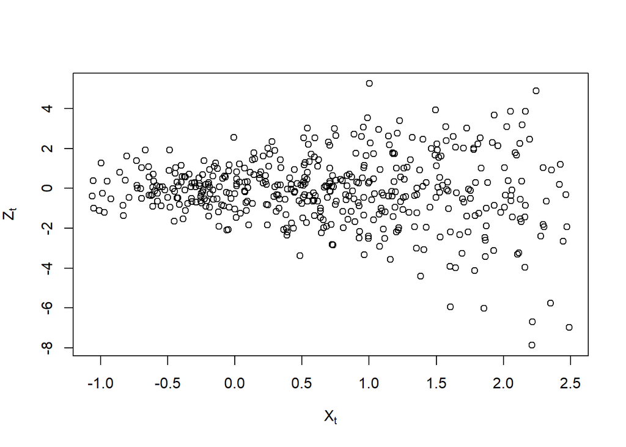

```r
plot(X_cut, Z_cut, xlab=expression(X[t]), ylab=expression(Z[t]))
```

### Theoretical Conditional VaR

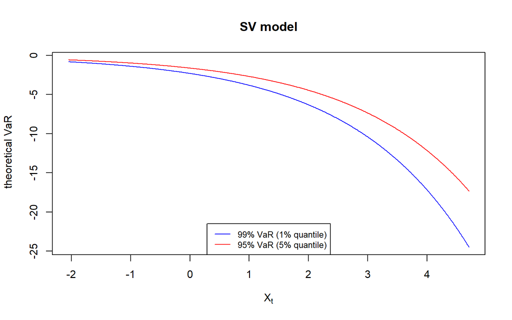

```r
# plot 95% & 99% Conditional VaR

# whole data
xx = seq(min(X),max(X),0.01)
plot(xx, theo_con_q(xx,1-0.99), col="blue", type="l",
     xlab=expression(X[t]), ylab=" theoretical VaR", main="SV model",
     ylim=c(min(theo_con_q(xx,1-0.99)),max(theo_con_q(xx,1-0.95))) )
lines(xx, theo_con_q(xx,1-0.95), col="red")
legend("bottom",legend=c("99% VaR (1% quantile)","95% VaR (5% quantile)"),
       col=c("blue","red"),lty=1, cex=0.8)
```

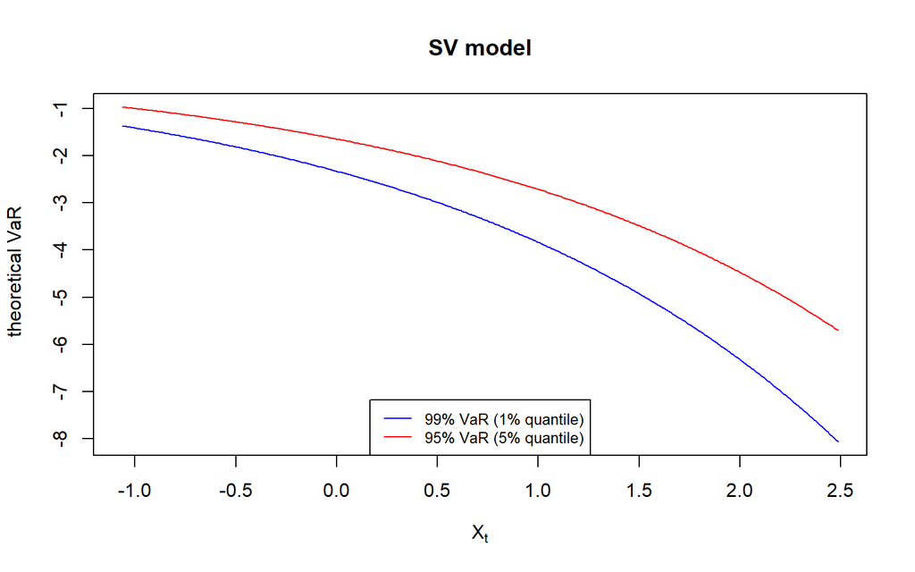

```r
# cutoff data
xx = seq(min(X_cut),max(X_cut),0.01)
plot(xx, theo_con_q(xx,1-0.99), col="blue", type="l",
     xlab=expression(X[t]), ylab=" theoretical VaR", main="SV model",
     ylim=c(min(theo_con_q(xx,1-0.99)),max(theo_con_q(xx,1-0.95))) )
lines(xx, theo_con_q(xx,1-0.95), col="red")
legend("bottom",legend=c("99% VaR (1% quantile)","95% VaR (5% quantile)"),
       col=c("blue","red"),lty=1, cex=0.8)
```

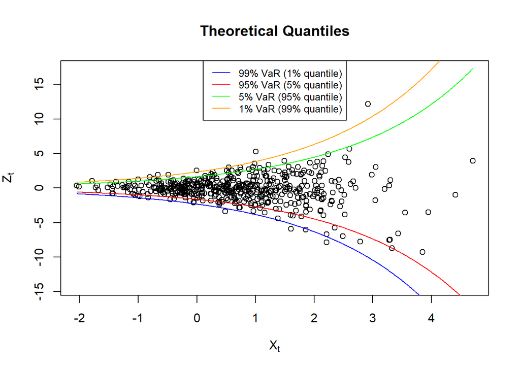

```r
# plot theoretical VaR on the scatterplot of {Xt, Zt} t=1,...,n
xx = seq(min(X),max(X),0.01)
plot(X, Z, ylim=c(min(Z)-5,max(Z)+5),
     xlab=expression(X[t]), ylab=expression(Z[t]), main="Theoretical Quantiles")
lines(xx, theo_con_q(xx,1-0.99), col="blue")
lines(xx, theo_con_q(xx,1-0.95), col="red")
lines(xx, theo_con_q(xx,1-0.05), col="green")
lines(xx, theo_con_q(xx,1-0.01), col="orange")
legend("top",legend=c("99% VaR (1% quantile)","95% VaR (5% quantile)",
                      "5% VaR (95% quantile)","1% VaR (99% quantile)"),
       col=c("blue","red","green","orange"),lty=1, cex=0.8)
```

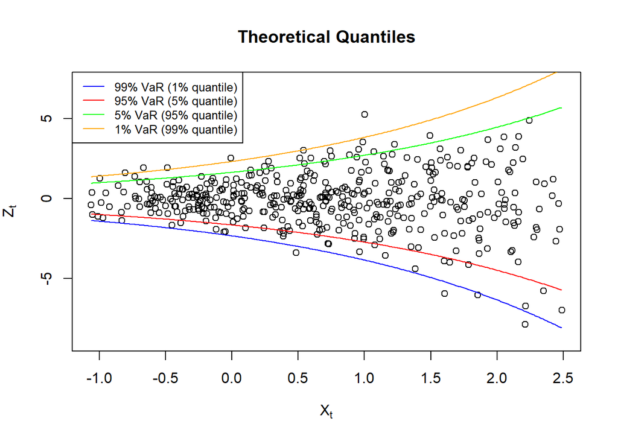

```r
# cutoff data
xx = seq(min(X_cut),max(X_cut),0.01)
plot(X_cut, Z_cut, ylim=c(min(Z_cut)-1,max(Z_cut)+2),
     xlab=expression(X[t]), ylab=expression(Z[t]), main="Theoretical Quantiles")
lines(xx, theo_con_q(xx,1-0.99), col="blue")
lines(xx, theo_con_q(xx,1-0.95), col="red")
lines(xx, theo_con_q(xx,1-0.05), col="green")
lines(xx, theo_con_q(xx,1-0.01), col="orange")
legend("topleft",legend=c("99% VaR (1% quantile)","95% VaR (5% quantile)",
                      "5% VaR (95% quantile)","1% VaR (99% quantile)"),
       col=c("blue","red","green","orange"),lty=1, cex=0.8)
```

In practical, people care about the 95% VaR (5% quantile) or 99% VaR (1% quantile), which represents the losses in the worst cases.

Question1: So should we care more about the 95% or 99% VaR?

### Estimating the Conditional VaR

The algorithm is:

for each $X=x_0$, find a quantile $\hat{\xi}(x_0)$ such that $F_n(\xi|x_0)$ is the closest to our percentile $p$, where:

$$F_n(\xi|x_0) = \frac{H_n(\xi,x_0)}{nb_nf_n(x_0)} = \frac{\sum\limits_{i=1}^n \mathbf{1}_{Z_i\leq\xi} K_{b_n}(x_0-X_i)}{\sum\limits_{i=1}^n K_{b_n}(x_0-X_i)} = \sum\limits_{i=1}^n \frac{K_{b_n}(x_0-X_i)}{\sum\limits_{i=1}^n K_{b_n}(x_0-X_i)} \mathbf{1}_{Z_i\leq\xi} = \sum\limits_{i=1}^n W_{b_n}(x_0-X_i) \mathbf{1}_{Z_i\leq\xi}$$

Then it is crucial that how we set up the grids for values of $X=x_0$ and the potential quantiles $\xi$.

1. Suppose $Z_1 \leq Z_2 \leq \cdots \leq Z_n$, then for all $Z_1 \leq \xi^* < Z_2$, the vector $\mathbf{1}_{Z\leq\xi^*} = (1,0,\cdots,0)^T$ is the same for these $\xi^*$, thus will get the same value $F_n(\xi^*|x_0)$. And within these $\xi^*$ values, it will choose the smallest $Z_1$ as one candidate. Therefore, when we are searching for potential quantiles $\xi$, we only need to search within the values of data $Z$, i.e. no need to set up a grid values of $\xi \in [min(Z),max(Z)]$.
2. For values of $X$, we estimate the quantiles for a grid values of $x \in [min(X),max(X)]$.

```r
# function for estimating conditional quantile
kernel_con_q_est = function(X,Z,p,h){

    # generate grids for X & Z(quantile) directions
    xx = seq(min(X), max(X), length.out=1000)
    #xx = X[order(X)]
    qq = Z[order(Z)]

    # calculate the weight Wi(x) for each x in the xx
    kernel_m = outer(xx,X,"-")
    kernel_d = dnorm(kernel_m/h)     # Gaussian Kernel with bandwidth h
    W = kernel_d / rowSums(kernel_d)

    # get the quantile q(x) for each x in the xx,  s.t. Fn(x) closest to p
    qq_est = rep(NA,length(xx))
    for (i in 1:length(xx)) {
        Fns = rep(NA,length(qq))
        for (j in 1:length(qq)) {
            Fns[j] = sum( W[i,]*(Z<=qq[j]) )  # element-wise production
        }
        index = which.min(abs(Fns-p))
        qq_est[i] = qq[index]
    }
    return(list(xx=xx, qq_est=qq_est))
}
```

```r
# estimate conditional quantile with "kernel conditional quantile estimation"
library(KernSmooth)

estimate_con_q = function(X,Z,p,h0.5=NULL,dpill_trim){
    # get h0.5 if not given
    if (is.null(h0.5)) {
        h0.5 = dpill(X,Z, trim=dpill_trim,      #  trim = min(0.05,10/length(X))
                     blockmax=ceiling(length(X)/10), divisor=10)
    }

    # calculate optimal h
    opt_h = (2/pi * p*(1-p) * dnorm(qnorm(p))^(-2) * h0.5^5) ^ (1/5)

    # estimate conditional quantile using opt_h
    qq_est1 = kernel_con_q_est(X,Z,p,opt_h)

    # estimate conditional quantile using sqrt(2)*opt_h
    qq_est2 = kernel_con_q_est(X,Z,p,sqrt(2)*opt_h)

    # bias correction
    qq_est = 2*qq_est1$qq_est - qq_est2$qq_est

    return(list(xx=qq_est1$xx, qq_est=qq_est, h0.5=h0.5, opt_h=opt_h))
}
```

#### Estimate the cutted data

```r
# estimate the conditional quantile (cutted)
est_01 = estimate_con_q(X_cut,Z_cut,p=1-0.99, dpill_trim=0.01)
est_05 = estimate_con_q(X_cut,Z_cut,p=1-0.95, dpill_trim=0.01)
c(est_01$h0.5, est_01$opt_h)
```

```
## [1] 0.3775848 0.5842849
```

```r
c(est_05$h0.5, est_05$opt_h)
```

```
## [1] 0.3775848 0.4653350
```

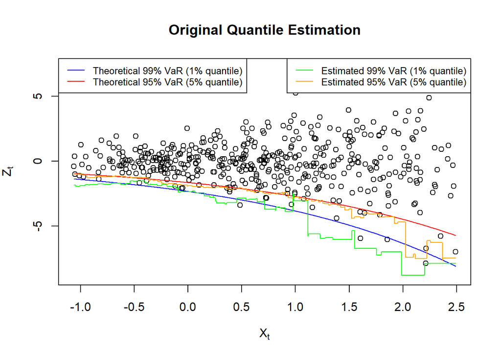

```r
# plot estimated VaR on the scatterplot of {Xt, Zt} t=1,...,n
plot(X_cut, Z_cut, ylim=c(min(Z_cut)-1,max(Z_cut)+2),
     xlab=expression(X[t]), ylab=expression(Z[t]), main="Original Quantile Estimation")
lines(est_01$xx, theo_con_q(est_01$xx,1-0.99), col="blue")
lines(est_05$xx, theo_con_q(est_05$xx,1-0.95), col="red")
lines(est_01$xx, est_01$qq_est, col="green")
lines(est_05$xx, est_05$qq_est, col="orange")
legend("topleft",col=c("blue","red"),lty=1, cex=0.8,
       legend=c("Theoretical 99% VaR (1% quantile)","Theoretical 95% VaR (5% quantile)"))
legend("topright",col=c("green","orange"),lty=1, cex=0.8,
       legend=c("Estimated 99% VaR (1% quantile)","Estimated 95% VaR (5% quantile)"))
```

#### 2nd smoothing: ksmooth()

```r
# select best smoothing bandwidth
bs = seq(0.1,max(est_01$xx)-min(est_01$xx),0.1)
DMAE_ksmooth = matrix(NA,length(bs),4)
colnames(DMAE_ksmooth) = c("bs","DMAE-1%","DMAE-5%","sum")
for (i in 1:length(bs)) {
    DMAE_ksmooth[i,1] = bs[i]
    est_01_s = ksmooth(est_01$xx,est_01$qq_est,kernel="normal",bandwidth=bs[i])$y
    est_05_s = ksmooth(est_05$xx,est_05$qq_est,kernel="normal",bandwidth=bs[i])$y
    DMAE_ksmooth[i,2] = mean(abs(theo_con_q(est_01$xx,1-0.99) - est_01_s))
    DMAE_ksmooth[i,3] = mean(abs(theo_con_q(est_05$xx,1-0.95) - est_05_s))
    DMAE_ksmooth[i,4] = mean(DMAE_ksmooth[i,2:3])
}
min_b_ksmooth_01 = DMAE_ksmooth[,1][which.min(DMAE_ksmooth[,2])]
min_b_ksmooth_05 = DMAE_ksmooth[,1][which.min(DMAE_ksmooth[,3])]
c(min_b_ksmooth_01, min_b_ksmooth_05)
```

```
## [1] 1.3 1.8
```

```r
c(min(DMAE_ksmooth[,2]), min(DMAE_ksmooth[,3]))
```

```
## [1] 0.4456553 0.3089547
```

```r
b_01 = dpill(est_01$xx,est_01$qq_est,trim=0.01)
b_05 = dpill(est_05$xx,est_05$qq_est,trim=0.01)
c(b_01, b_05)
```

```
## [1] 0.02823711 0.02972755
```

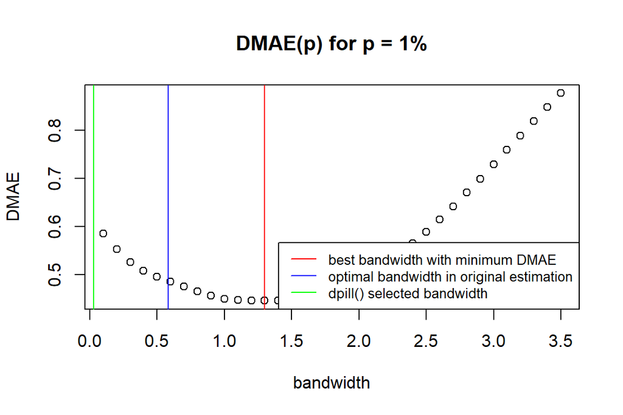

```r
plot(DMAE_ksmooth[,2]~DMAE_ksmooth[,1],xlab="bandwidth",ylab="DMAE",main="DMAE(p) for p = 1%")
abline(v=min_b_ksmooth_01,col="red")
abline(v=est_01$opt_h,col="blue")
abline(v=b_01,col="green")
legend("bottomright",legend=c("best bandwidth with minimum DMAE","optimal bandwidth in original estimation","dpill() selected bandwidth"), col=c("red","blue","green"), lty=1, cex=0.8)
```

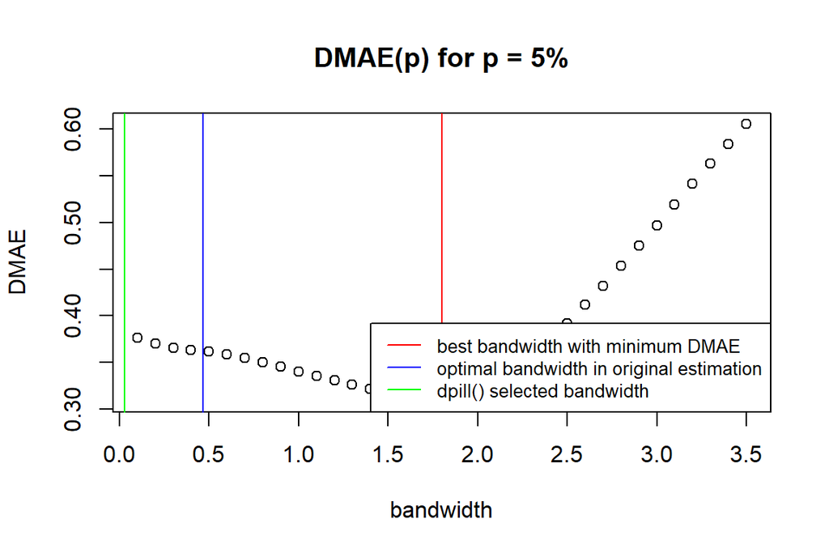

```r
plot(DMAE_ksmooth[,3]~DMAE_ksmooth[,1],xlab="bandwidth",ylab="DMAE",main="DMAE(p) for p = 5%")
abline(v=min_b_ksmooth_05,col="red")
abline(v=est_05$opt_h,col="blue")
abline(v=b_05,col="green")
legend("bottomright",legend=c("best bandwidth with minimum DMAE","optimal bandwidth in original estimation","dpill() selected bandwidth"), col=c("red","blue","green"), lty=1, cex=0.8)
```

# 2nd smoothing: locpoly() - degree = 2

```r
# select best smoothing bandwidth
bs = seq(0.1,max(est_01$xx)-min(est_01$xx),0.1)
DMAE_locpoly = matrix(NA,length(bs),4)
colnames(DMAE_locpoly) = c("bs","DMAE-1%","DMAE-5%","sum")
for (i in 1:length(bs)) {
    DMAE_locpoly[i,1] = bs[i]
    est_01_s = locpoly(est_01$xx,est_01$qq_est,kernel="normal",bandwidth=bs[i],
                                                        gridsize=1000,degree=2)$y
    est_05_s = locpoly(est_05$xx,est_05$qq_est,kernel="normal",bandwidth=bs[i],
                                                        gridsize=1000,degree=2)$y
    DMAE_locpoly[i,2] = mean(abs(theo_con_q(est_01$xx,1-0.99) - est_01_s))
    DMAE_locpoly[i,3] = mean(abs(theo_con_q(est_05$xx,1-0.95) - est_05_s))
    DMAE_locpoly[i,4] = mean(DMAE_locpoly[i,2:3])
}
min_b_locpoly_01 = DMAE_locpoly[,1][which.min(DMAE_locpoly[,2])]
min_b_locpoly_05 = DMAE_locpoly[,1][which.min(DMAE_locpoly[,3])]
c(min_b_locpoly_01, min_b_locpoly_05)
```

```
## [1] 3.5 0.3
```

```r
c(min(DMAE_locpoly[,2]), min(DMAE_locpoly[,3]))
```

```
## [1] 0.4624987 0.3538685
```

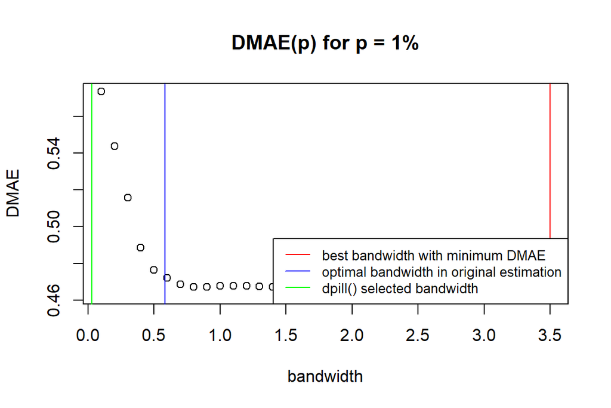

```r
plot(DMAE_locpoly[,2]~DMAE_locpoly[,1],xlab="bandwidth",ylab="DMAE",main="DMAE(p) for p = 1%")
abline(v=min_b_locpoly_01,col="red")
abline(v=est_01$opt_h,col="blue")
abline(v=b_01,col="green")
legend("bottomright",legend=c("best bandwidth with minimum DMAE","optimal bandwidth in original estimation","dpill() selected bandwidth"), col=c("red","blue","green"), lty=1, cex=0.8)
```

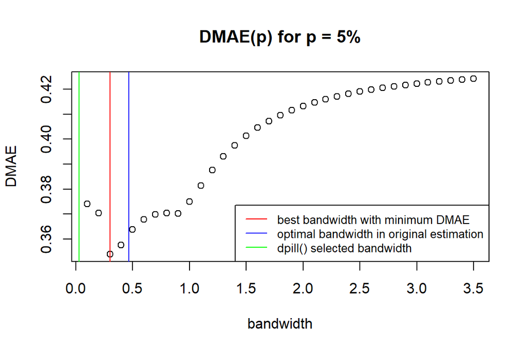

```r
plot(DMAE_locpoly[,3]~DMAE_locpoly[,1],xlab="bandwidth",ylab="DMAE",main="DMAE(p) for p = 5%")
abline(v=min_b_locpoly_05,col="red")
abline(v=est_05$opt_h,col="blue")
abline(v=b_05,col="green")
legend("bottomright",legend=c("best bandwidth with minimum DMAE","optimal bandwidth in original estimation","dpill() selected bandwidth"), col=c("red","blue","green"), lty=1, cex=0.8)
```

#### The Plot for ksmooth & locpoly

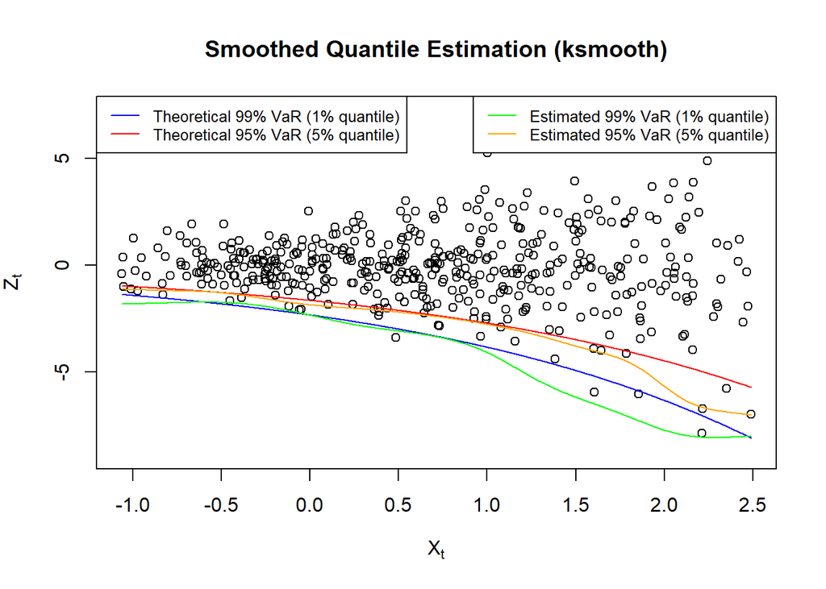

```r
# plot estimated VaR on the scatterplot of {Xt, Zt} t=1,...,n  (cutted)
plot(X_cut, Z_cut, ylim=c(min(Z_cut)-1,max(Z_cut)+2),
     xlab=expression(X[t]), ylab=expression(Z[t]), main="Smoothed Quantile Estimation (ksmooth)")
lines(est_01$xx, theo_con_q(est_01$xx,1-0.99), col="blue")
lines(est_05$xx, theo_con_q(est_05$xx,1-0.95), col="red")
lines(ksmooth(est_01$xx,est_01$qq_est,kernel="normal",bandwidth=est_01$opt_h), col="green")
lines(ksmooth(est_05$xx,est_05$qq_est,kernel="normal",bandwidth=est_05$opt_h), col="orange")
legend("topleft",col=c("blue","red"),lty=1, cex=0.8,
       legend=c("Theoretical 99% VaR (1% quantile)","Theoretical 95% VaR (5% quantile)"))
legend("topright",col=c("green","orange"),lty=1, cex=0.8,
       legend=c("Estimated 99% VaR (1% quantile)","Estimated 95% VaR (5% quantile)"))
```

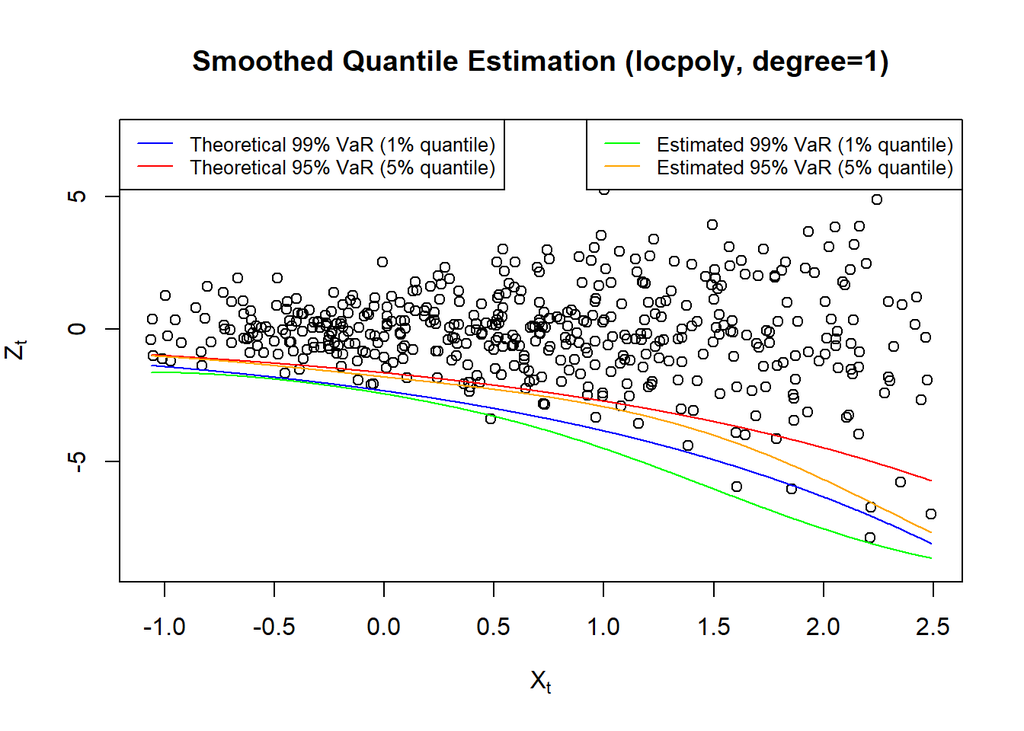

```r
# plot estimated VaR on the scatterplot of {Xt, Zt} t=1,...,n  (cutted)
plot(X_cut, Z_cut, ylim=c(min(Z_cut)-1,max(Z_cut)+2),
     xlab=expression(X[t]), ylab=expression(Z[t]), main="Smoothed Quantile Estimation (locpoly, degree=1)")
lines(est_01$xx, theo_con_q(est_01$xx,1-0.99), col="blue")
lines(est_05$xx, theo_con_q(est_05$xx,1-0.95), col="red")
lines(locpoly(est_01$xx,est_01$qq_est,kernel="normal",bandwidth=est_01$opt_h,gridsize=1000), col="green")
lines(locpoly(est_05$xx,est_05$qq_est,kernel="normal",bandwidth=est_05$opt_h,gridsize=1000), col="orange")
legend("topleft",col=c("blue","red"),lty=1, cex=0.8,
       legend=c("Theoretical 99% VaR (1% quantile)","Theoretical 95% VaR (5% quantile)"))
legend("topright",col=c("green","orange"),lty=1, cex=0.8,
       legend=c("Estimated 99% VaR (1% quantile)","Estimated 95% VaR (5% quantile)"))
```

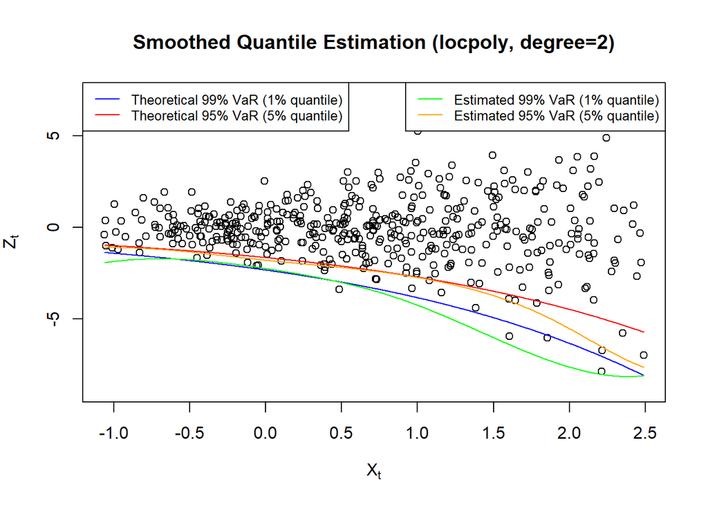

```r
# plot estimated VaR on the scatterplot of {Xt, Zt} t=1,...,n  (cutted)
plot(X_cut, Z_cut, ylim=c(min(Z_cut)-1,max(Z_cut)+2),
     xlab=expression(X[t]), ylab=expression(Z[t]), main="Smoothed Quantile Estimation (locpoly, degree=2)")
lines(est_01$xx, theo_con_q(est_01$xx,1-0.99), col="blue")
lines(est_05$xx, theo_con_q(est_05$xx,1-0.95), col="red")
lines(locpoly(est_01$xx,est_01$qq_est,kernel="normal",bandwidth=est_01$opt_h,gridsize=1000,degree=2), col="green")
lines(locpoly(est_05$xx,est_05$qq_est,kernel="normal",bandwidth=est_05$opt_h,gridsize=1000,degree=2), col="orange")
legend("topleft",col=c("blue","red"),lty=1, cex=0.8,
       legend=c("Theoretical 99% VaR (1% quantile)","Theoretical 95% VaR (5% quantile)"))
legend("topright",col=c("green","orange"),lty=1, cex=0.8,
       legend=c("Estimated 99% VaR (1% quantile)","Estimated 95% VaR (5% quantile)"))
```

### Calculate the DMAE for multiple simulations

```r
# function for running multiple simulations and calculate the average DMAE

average_DMAE = function(n_sample, n_sim){

    total.start = Sys.time()

    DMAEs_ksm0.01 = DMAEs_ksm0.05 = NULL
    DMAEs_loc0.01 = DMAEs_loc0.05 = NULL
    DMAEs_loc0.01_d2 = DMAEs_loc0.05_d2 = NULL

    theo_q_range0.01 = theo_q_range0.05 = matrix(NA,n_sim,2)

    Z_range = matrix(NA,n_sim,2)

    while (length(DMAEs_ksm0.01)<n_sim) {

        # generate sample {Xt,Zt} t=1,...,n
        data = simulate_data(n_sample, cutoff=0.05)
        X = data$X_cut
        Z = data$Z_cut

        # get h0.5
        h0.5 = try( dpill(X,Z, trim=0.01,
                    blockmax=ceiling(length(X)/10),divisor=10), silent=TRUE)
        # skip to next simulation if function gets: NaN or error(bandwidth<=0)
        if (is.na(h0.5) | !is.numeric(h0.5)) { next }

        #######################################  0.01
        # estimate the conditional quantile
        con_q_est = estimate_con_q(X,Z,p=0.01,h0.5)

        # 2nd kernel smoothing of the estimates
        qq_est_ksm0.01 = ksmooth(con_q_est$xx,con_q_est$qq_est,
                                 kernel="normal",bandwidth=con_q_est$opt_h)$y
        qq_est_loc0.01 = locpoly(con_q_est$xx,con_q_est$qq_est,
                                 kernel="normal",bandwidth=con_q_est$opt_h,gridsize=1000)$y
        qq_est_loc0.01_d2 = locpoly(con_q_est$xx,con_q_est$qq_est,
                                 kernel="normal",bandwidth=con_q_est$opt_h,gridsize=1000,
                                                                                degree=2)$y
        #######################################  0.01

        #######################################  0.05
        # estimate the conditional quantile
        con_q_est = estimate_con_q(X,Z,p=0.05,h0.5)

        # 2nd kernel smoothing of the estimates
        qq_est_ksm0.05 = ksmooth(con_q_est$xx,con_q_est$qq_est,
                                 kernel="normal",bandwidth=con_q_est$opt_h)$y
        qq_est_loc0.05 = locpoly(con_q_est$xx,con_q_est$qq_est,
                                 kernel="normal",bandwidth=con_q_est$opt_h,gridsize=1000)$y
        qq_est_loc0.05_d2 = locpoly(con_q_est$xx,con_q_est$qq_est,
                                 kernel="normal",bandwidth=con_q_est$opt_h,gridsize=1000,
                                                                                degree=2)$y
        #######################################  0.05

        # calculate the theoretical conditional quantile
        theo_qq0.01 = theo_con_q(con_q_est$xx, p=0.01)
        theo_qq0.05 = theo_con_q(con_q_est$xx, p=0.05)

        # calculate DMAE
        DMAEs_ksm0.01 = c(DMAEs_ksm0.01, mean(abs(qq_est_ksm0.01 - theo_qq0.01)))
        DMAEs_loc0.01 = c(DMAEs_loc0.01, mean(abs(qq_est_loc0.01 - theo_qq0.01)))
        DMAEs_loc0.01_d2 = c(DMAEs_loc0.01_d2, mean(abs(qq_est_loc0.01_d2 - theo_qq0.01)))


        DMAEs_ksm0.05 = c(DMAEs_ksm0.05, mean(abs(qq_est_ksm0.05 - theo_qq0.05)))
        DMAEs_loc0.05 = c(DMAEs_loc0.05, mean(abs(qq_est_loc0.05 - theo_qq0.05)))
        DMAEs_loc0.05_d2 = c(DMAEs_loc0.05_d2, mean(abs(qq_est_loc0.05_d2 - theo_qq0.05)))

        # store the range of theoretical conditional quantile
        theo_q_range0.01[length(DMAEs_ksm0.01), ] = c(min(theo_qq0.01), max(theo_qq0.01))
        theo_q_range0.05[length(DMAEs_ksm0.05), ] = c(min(theo_qq0.05), max(theo_qq0.05))

        # store the range of X & Z
        Z_range[length(DMAEs_ksm0.01), ] = c(min(Z),max(Z))

        print(length(DMAEs_ksm0.01))
    }

    total.time = as.numeric(Sys.time() - total.start)

    list0.01 = list(DMAEs_ksm=DMAEs_ksm0.01, ksm=mean(DMAEs_ksm0.01),
                    DMAEs_loc=DMAEs_loc0.01, loc=mean(DMAEs_loc0.01),
                    DMAEs_loc_d2=DMAEs_loc0.01_d2, loc_d2=mean(DMAEs_loc0.01_d2),
                    theo_q_range=theo_q_range0.01)

    list0.05 = list(DMAEs_ksm=DMAEs_ksm0.05, ksm=mean(DMAEs_ksm0.05),
                    DMAEs_loc=DMAEs_loc0.05, loc=mean(DMAEs_loc0.05),
                    DMAEs_loc_d2=DMAEs_loc0.05_d2, loc_d2=mean(DMAEs_loc0.05_d2),
                    theo_q_range=theo_q_range0.05)

    return(list(list0.01=list0.01, list0.05=list0.05, Z_range=Z_range,
                total.time=total.time))
}
```

```r
set.seed(123)
DMAE_250 = average_DMAE(n_sample=250, n_sim=100)
DMAE_500 = average_DMAE(n_sample=500, n_sim=100)
DMAE_1000 = average_DMAE(n_sample=1000, n_sim=100)

save(DMAE_250, DMAE_500, DMAE_1000,
     file='sim_SV.RData')
```

```r
load('sim_SV.RData')
c(DMAE_250$list0.01$ksm, DMAE_250$list0.01$loc, DMAE_250$list0.01$loc_d2)
c(DMAE_250$list0.05$ksm, DMAE_250$list0.05$loc, DMAE_250$list0.05$loc_d2)

c(DMAE_500$list0.01$ksm, DMAE_500$list0.01$loc, DMAE_500$list0.01$loc_d2)
c(DMAE_500$list0.05$ksm, DMAE_500$list0.05$loc, DMAE_500$list0.05$loc_d2)

c(DMAE_1000$list0.01$ksm, DMAE_1000$list0.01$loc, DMAE_1000$list0.01$loc_d2)
c(DMAE_1000$list0.05$ksm, DMAE_1000$list0.05$loc, DMAE_1000$list0.05$loc_d2)
```

```r
c(min(DMAE_250$Z_range[,1]), max(DMAE_250$Z_range[,2]))
c(min(DMAE_500$Z_range[,1]), max(DMAE_500$Z_range[,2]))
c(min(DMAE_1000$Z_range[,1]), max(DMAE_1000$Z_range[,2]))
```

```r
c(min(DMAE_250$list0.01$theo_q_range[,1]), max(DMAE_250$list0.01$theo_q_range[,2]))
c(min(DMAE_250$list0.05$theo_q_range[,1]), max(DMAE_250$list0.05$theo_q_range[,2]))

c(min(DMAE_500$list0.01$theo_q_range[,1]), max(DMAE_500$list0.01$theo_q_range[,2]))
c(min(DMAE_500$list0.05$theo_q_range[,1]), max(DMAE_500$list0.05$theo_q_range[,2]))

c(min(DMAE_1000$list0.01$theo_q_range[,1]), max(DMAE_1000$list0.01$theo_q_range[,2]))
c(min(DMAE_1000$list0.05$theo_q_range[,1]), max(DMAE_1000$list0.05$theo_q_range[,2]))
```

calculate for every simulation

```r
mean(DMAE_250$list0.01$DMAEs_ksm/(DMAE_250$Z_range[,2]-DMAE_250$Z_range[,1]))
mean(DMAE_250$list0.05$DMAEs_ksm/(DMAE_250$Z_range[,2]-DMAE_250$Z_range[,1]))

mean(DMAE_500$list0.01$DMAEs_ksm/(DMAE_500$Z_range[,2]-DMAE_500$Z_range[,1]))
mean(DMAE_500$list0.05$DMAEs_ksm/(DMAE_500$Z_range[,2]-DMAE_500$Z_range[,1]))

mean(DMAE_1000$list0.01$DMAEs_ksm/(DMAE_1000$Z_range[,2]-DMAE_1000$Z_range[,1]))
mean(DMAE_1000$list0.05$DMAEs_ksm/(DMAE_1000$Z_range[,2]-DMAE_1000$Z_range[,1]))
```

```r
mean(DMAE_250$list0.01$DMAEs_ksm/(DMAE_250$list0.01$theo_q_range[,2]-DMAE_250$list0.01$theo_q_range[,1]))
mean(DMAE_250$list0.05$DMAEs_ksm/(DMAE_250$list0.05$theo_q_range[,2]-DMAE_250$list0.05$theo_q_range[,1]))

mean(DMAE_500$list0.01$DMAEs_ksm/(DMAE_500$list0.01$theo_q_range[,2]-DMAE_500$list0.01$theo_q_range[,1]))
mean(DMAE_500$list0.05$DMAEs_ksm/(DMAE_500$list0.05$theo_q_range[,2]-DMAE_500$list0.05$theo_q_range[,1]))

mean(DMAE_1000$list0.01$DMAEs_ksm/(DMAE_1000$list0.01$theo_q_range[,2]-DMAE_1000$list0.01$theo_q_range[,1]))
mean(DMAE_1000$list0.05$DMAEs_ksm/(DMAE_1000$list0.05$theo_q_range[,2]-DMAE_1000$list0.05$theo_q_range[,1]))
```

estimation time

```r
# min (or hour), second
c(DMAE_250$total.time, DMAE_250$total.time/2*60/100)
c(DMAE_500$total.time, DMAE_500$total.time/2*60/100)
c(DMAE_1000$total.time, DMAE_1000$total.time/2*60*60/100)
```

# Appendix: Other methods: np package

```r
# np for cutted data
library(np)
bw = npcdistbw(Z_cut~X_cut, tol=0.1, ftol=0.1)
q0.01 = npqreg(bws=bw, tau=0.01)
q0.05 = npqreg(bws=bw, tau=0.05)

# bandwidth used for X & Z (same for 0.01 & 0.05)
c(bw$xbw, bw$ybw)
```

```r
plot(X_cut, Z_cut, ylim=c(min(Z_cut)-1,max(Z_cut)+2),
     xlab=expression(X[t]), ylab=expression(Z[t]), main="Smoothed Estimated Quantiles")
lines(est_01$xx, theo_con_q(est_01$xx,1-0.99), col="blue")
lines(est_05$xx, theo_con_q(est_05$xx,1-0.95), col="red")
lines(X_cut[order(X_cut)], q0.01$quantile[order(X_cut)], col="green")
lines(X_cut[order(X_cut)], q0.05$quantile[order(X_cut)], col="orange")
legend("topleft",col=c("blue","red"),lty=1, cex=0.8,
       legend=c("Theoretical 99% VaR (1% quantile)","Theoretical 95% VaR (5% quantile)"))
legend("topright",col=c("green","orange"),lty=1, cex=0.8,
       legend=c("Estimated 99% VaR (1% quantile)","Estimated 95% VaR (5% quantile)"))
```